# 拍拍贷用户借款数据分析

## 数据集介绍

此数据集来自于拍拍贷互金训练营，提供的数据来自拍拍贷真实业务数据，从2015-01-01到2017-01-30的所有信用标的10%sample样本。数据集包含LC.csv（标的特征表数据）和LP.csv（标的还款计划和还款记录表）数据。在本项目中，选用了LC.csv数据集进行分析。

## 观察数据

```
## [1] 328553     21
```

```
## 'data.frame':    328553 obs. of  21 variables:
##  $ ListingId       : int  126541 133291 142421 149711 152141 162641 171191 175451 182261 193831 ...
##  $ 借款金额        : int  18000 9453 27000 25000 20000 20000 3940 20000 25000 10475 ...
##  $ 借款期限        : int  12 12 24 12 6 12 6 12 12 6 ...
##  $ 借款利率        : num  18 20 20 18 16 14 18 18 16 18 ...
##  $ 借款成功日期    : Factor w/ 756 levels "2015-01-01","2015-01-02",..: 119 70 477 84 22 79 172 439 75 100 ...
##  $ 初始评级        : Factor w/ 6 levels "A","B","C","D",..: 3 4 5 3 3 1 5 2 2 3 ...
##  $ 借款类型        : Factor w/ 4 levels "APP闪电","电商",..: 4 4 3 4 2 3 2 3 4 2 ...
##  $ 是否首标        : Factor w/ 2 levels "否","是": 1 1 1 1 1 1 1 1 1 1 ...
##  $ 年龄            : int  35 34 41 34 24 36 27 32 33 25 ...
##  $ 性别            : Factor w/ 2 levels "男","女": 1 1 1 1 1 1 2 1 2 1 ...
##  $ 手机认证        : Factor w/ 2 levels "成功认证","未成功认证": 1 2 1 1 1 1 1 1 1 1 ...
##  $ 户口认证        : Factor w/ 2 levels "成功认证","未成功认证": 2 1 2 1 1 1 1 1 2 1 ...
##  $ 视频认证        : Factor w/ 2 levels "成功认证","未成功认证": 1 2 2 1 1 1 1 1 1 1 ...
##  $ 学历认证        : Factor w/ 2 levels "成功认证","未成功认证": 2 2 2 2 2 2 2 2 2 2 ...
##  $ 征信认证        : Factor w/ 2 levels "成功认证","未成功认证": 2 2 2 2 2 2 2 2 2 2 ...
##  $ 淘宝认证        : Factor w/ 2 levels "成功认证","未成功认证": 2 2 2 2 2 2 2 2 2 2 ...
##  $ 历史成功借款次数: int  11 4 5 6 13 7 15 7 7 9 ...
##  $ 历史成功借款金额: num  40326 14500 21894 36190 77945 ...
##  $ 总待还本金      : num  8713 7891 11726 9703 0 ...
##  $ 历史正常还款期数: int  57 13 25 41 118 56 75 52 41 49 ...
##  $ 历史逾期还款期数: int  16 1 3 1 14 0 8 0 2 4 ...
```

```
##    ListingId           借款金额         借款期限        借款利率
##  Min.   :  126541   Min.   :   100   Min.   : 1.00   Min.   : 6.5
##  1st Qu.:11908871   1st Qu.:  2033   1st Qu.: 6.00   1st Qu.:20.0
##  Median :19523251   Median :  3397   Median :12.00   Median :20.0
##  Mean   :19079479   Mean   :  4424   Mean   :10.21   Mean   :20.6
##  3rd Qu.:26298621   3rd Qu.:  5230   3rd Qu.:12.00   3rd Qu.:22.0
##  Max.   :32819531   Max.   :500000   Max.   :24.00   Max.   :24.0
##
##      借款成功日期    初始评级      借款类型      是否首标
##  2017-01-25:  3558   A: 10284   APP闪电:112079   否:241090
##  2017-01-20:  3063   B: 33188   电商   :  1069   是: 87463
##  2016-12-14:  2266   C:131705   普通   :118103
##  2016-12-02:  2033   D:134860   其他   : 97302
##  2017-01-09:  1859   E: 17027
##  2017-01-04:  1806   F:  1489
##  (Other)   :313968
##       年龄       性别              手机认证            户口认证
##  Min.   :17.00   男:221946   成功认证  :123007   成功认证  : 10105
##  1st Qu.:24.00   女:106607   未成功认证:205546   未成功认证:318448
##  Median :28.00
##  Mean   :29.14
##  3rd Qu.:33.00
##  Max.   :56.00
##
##        视频认证            学历认证            征信认证
##  成功认证  : 18501   成功认证  :114124   成功认证  :  9606
##  未成功认证:310052   未成功认证:214429   未成功认证:318947
##
##
##
##
##
##        淘宝认证      历史成功借款次数  历史成功借款金额    总待还本金
##  成功认证  :  1152   Min.   :  0.000   Min.   :      0   Min.   :      0
##  未成功认证:327401   1st Qu.:  0.000   1st Qu.:      0   1st Qu.:      0
##                      Median :  2.000   Median :   5000   Median :   2542
##                      Mean   :  2.323   Mean   :   8786   Mean   :   3722
##                      3rd Qu.:  3.000   3rd Qu.:  10355   3rd Qu.:   5447
##                      Max.   :649.000   Max.   :7405926   Max.   :1172653
##
##  历史正常还款期数   历史逾期还款期数
##  Min.   :   0.000   Min.   : 0.0000
##  1st Qu.:   0.000   1st Qu.: 0.0000
##  Median :   5.000   Median : 0.0000
##  Mean   :   9.948   Mean   : 0.4233
##  3rd Qu.:  13.000   3rd Qu.: 0.0000
##  Max.   :2507.000   Max.   :60.0000
##
```

所选数据集由21个变量和328553个观察结果，其中变量包括11个类别变量和10个数值变量。  
在p2p企业中，用户还款逾期会对公司的资金链产生冲击，欠款金额越高，逾期时间越久，冲击就会越大，为了减少这种冲击，我们应该尽可能的降低逾期事件的概率。 所以在此项目中，我们的目标是通过对现有数据的分析及可视化，指出具有哪些特征的标容易逾期，从而引导借贷公司对申请借贷的用户特征和借款需求进行评估和筛选，对逾期可能性较高的用户予以不借款或降低借款金额或提高借款利息，来降低风险；对逾期可能性较低的用户予以提高借款金额或降低借款利息等措施，来提高收益。

如果只比较不同用户的`历史逾期还款期数`的话，会因为总的借款期数不同而产生干扰，为此，我们创建一个新的数据变量`逾期比`来作为比较，`逾期比` = `历史逾期还款期数` / (`历史正常还款期数` + `历史逾期还款期数`)，`逾期比`的范围在0到1之间，逾期比越接近于1，表示该用户越容易逾期。

## 单变量绘图

### 逾期比的分布情况

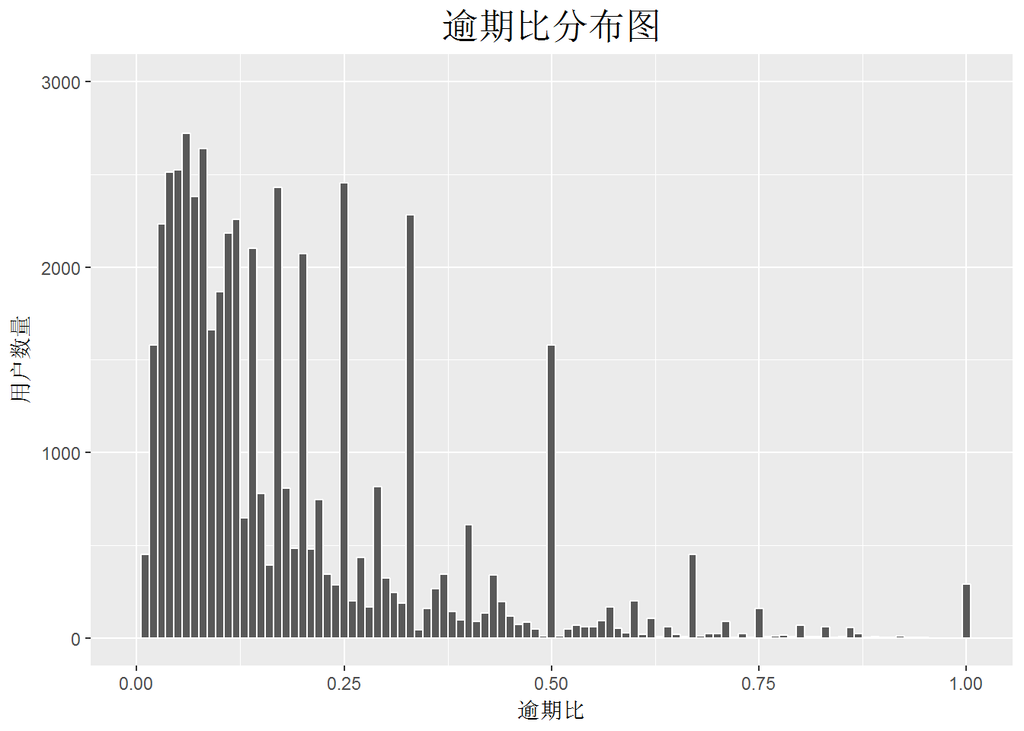

```
##    Min. 1st Qu.  Median    Mean 3rd Qu.    Max.
## 0.00000 0.00000 0.00000 0.03908 0.00000 1.00000
```

由`逾期比分布图`中可以看出，大部分人的逾期比在0.25以下，但是在0.33,0.5,0.67和1处均出现了尖峰值，这说明具有高逾期比的用户数量并不少；从summary中可以看出，用户的平均逾期比为0.04，也就是平均每100期还款中，就有约4期是逾期还款的。

### 借款金额的分布情况

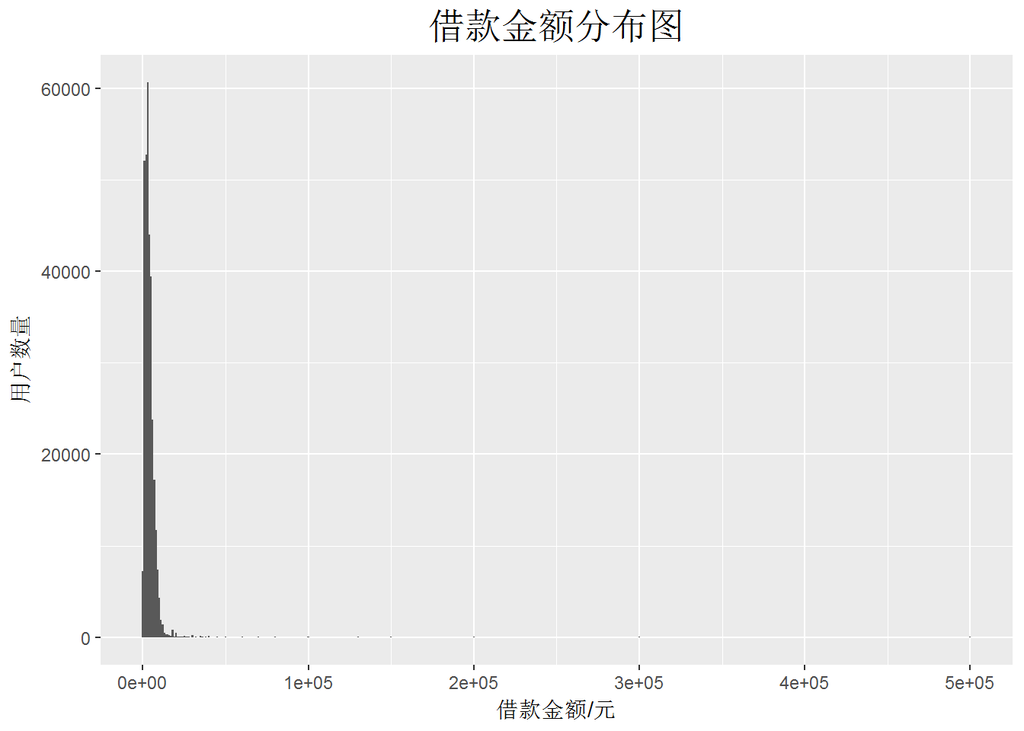

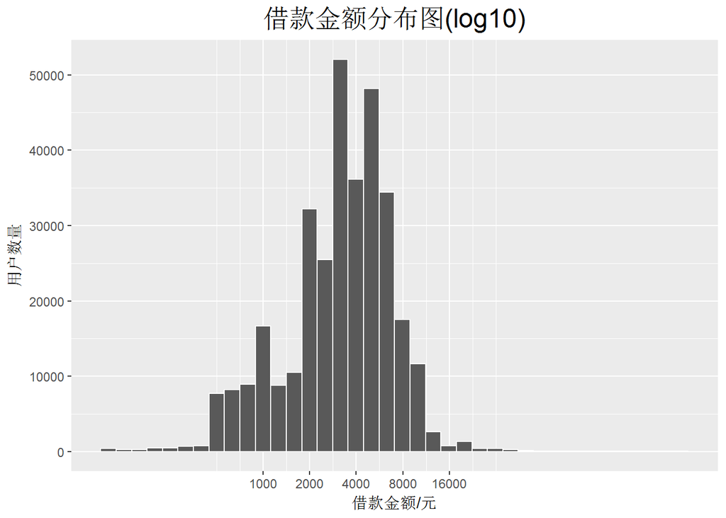

```
##    Min. 1st Qu.  Median    Mean 3rd Qu.    Max.
##     100    2033    3397    4424    5230  500000
```

由于用户的借款金额跨度比较大，且有着较低借款金额的用户数量远多于较高借款金额的用户，为方便查看，我们将x轴转为对数坐标。从图中可以看出，借款金额主要集中在2000-8000元之间；从summary中可以看出，借款金额的均值为4424元，最高值高达50万元。  
为方便后续分析比较，我们对借款金额进行分组，如下所示：  
(0,2000]  
(2000,5000]  
(5000,8000]  
(8000,500000]

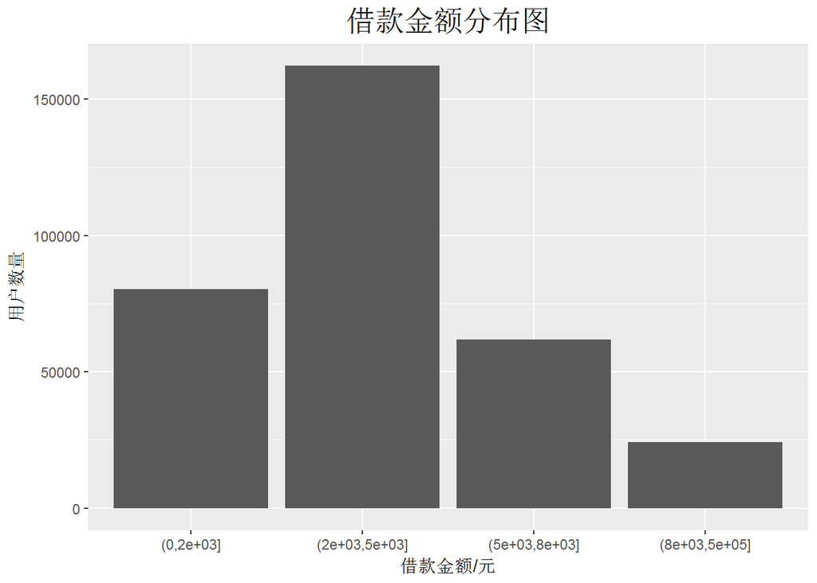

从图中可以看出，2000-5000元的借款金额最为普遍，其次是2000元以下和5000-8000元，8000元以上的借款金额最少。

### 借款期限的分布情况

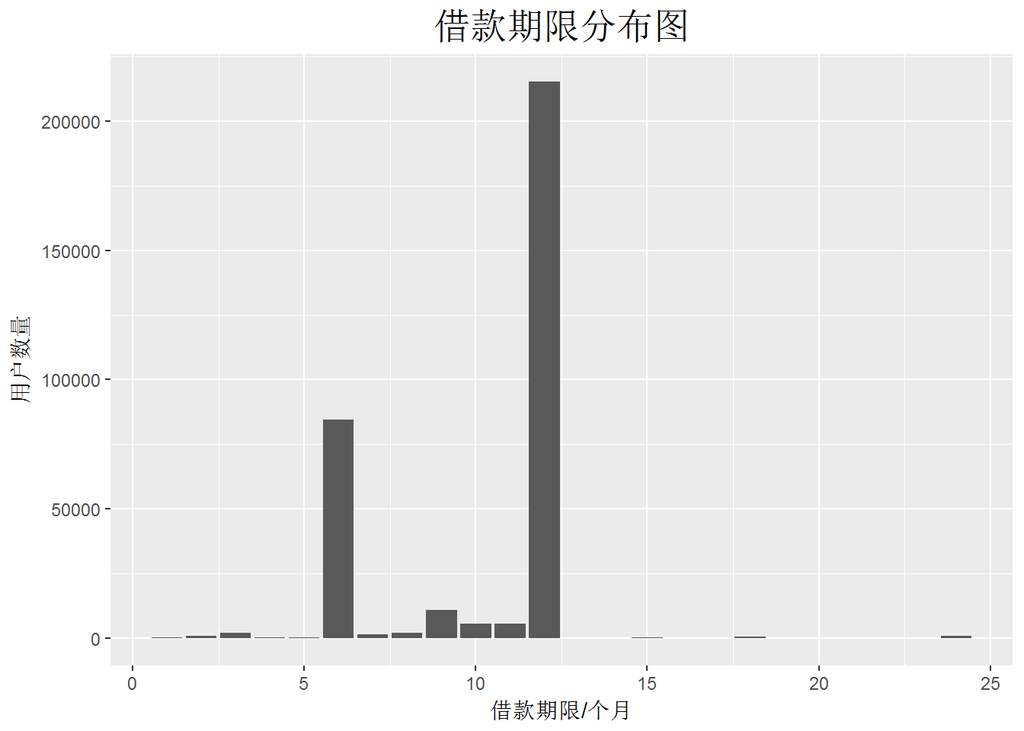

```
##
##      1      2      3      4      5      6      7      8      9     10
##     42    802   1993     94     85  84486   1239   1852  10769   5472
##     11     12     15     17     18     20     21     24
##   5351 215330     31      1    367      1      2    636
```

从图中可以看出，绝大部分人都选择了12个月（一年）分期或6个月（半年）分期还款的方式。

### 借款利率的分布情况

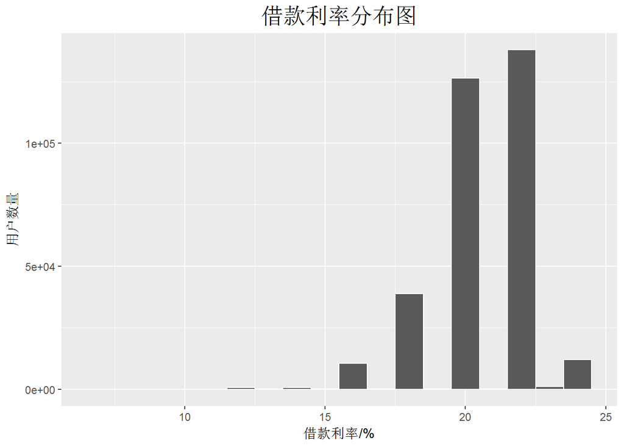

从图中可以看出，借款利率（年化）大部分都在20%及以上。

### 用户初始评级的分布情况

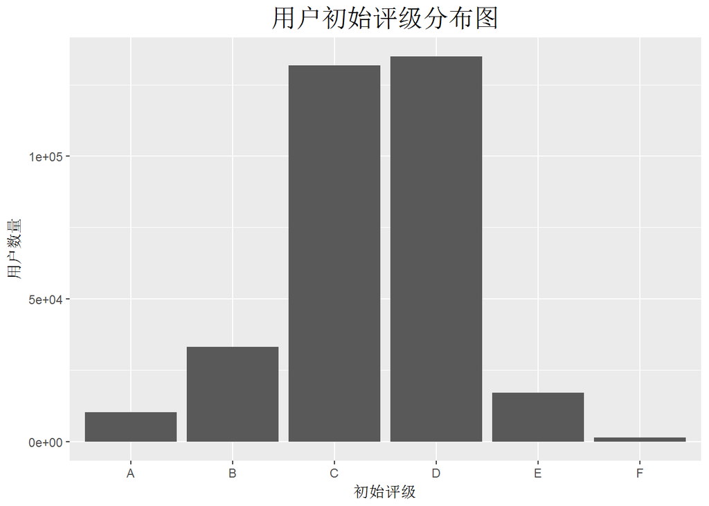

```
##
##      A      B      C      D      E      F
##  10284  33188 131705 134860  17027   1489
```

从图中可以看出，用户的初始评级集中在C和D等级。

### 借款类型的分布情况

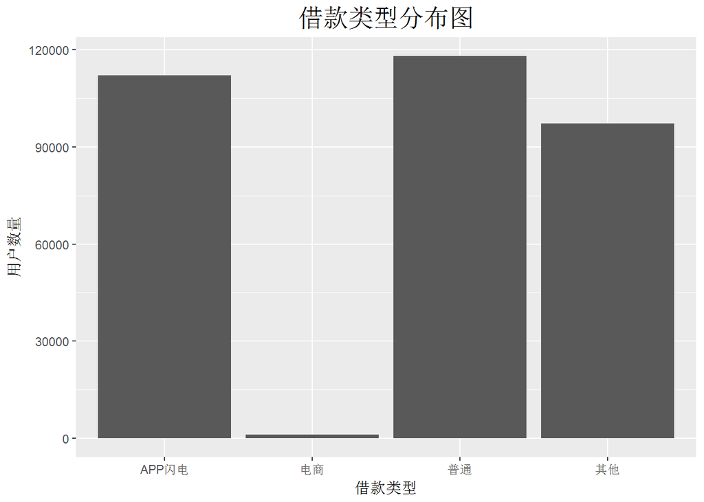

```
##
## APP闪电    电商    普通    其他
##  112079    1069  118103   97302
```

从图中可以看出，借款类型集中在APP闪电型和普通型，其他型稍次之，电商型最少。

### 用户是否首标分布情况

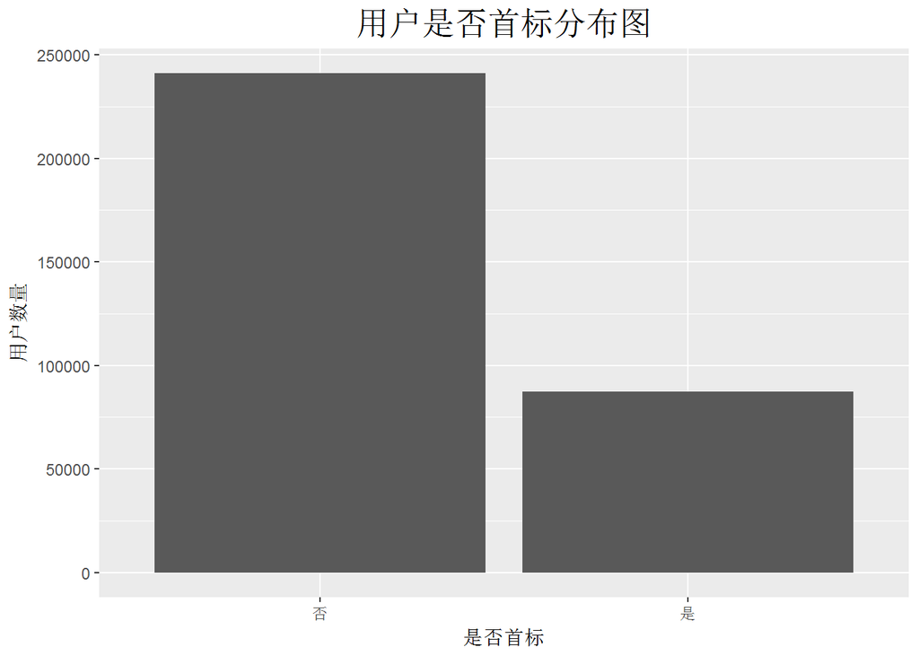

```
##
##     否     是
## 241090  87463
```

从图中可以看出，用户中大约包含3/4的老用户（非首标）和1/4的新用户（首标）。

### 用户年龄分布情况

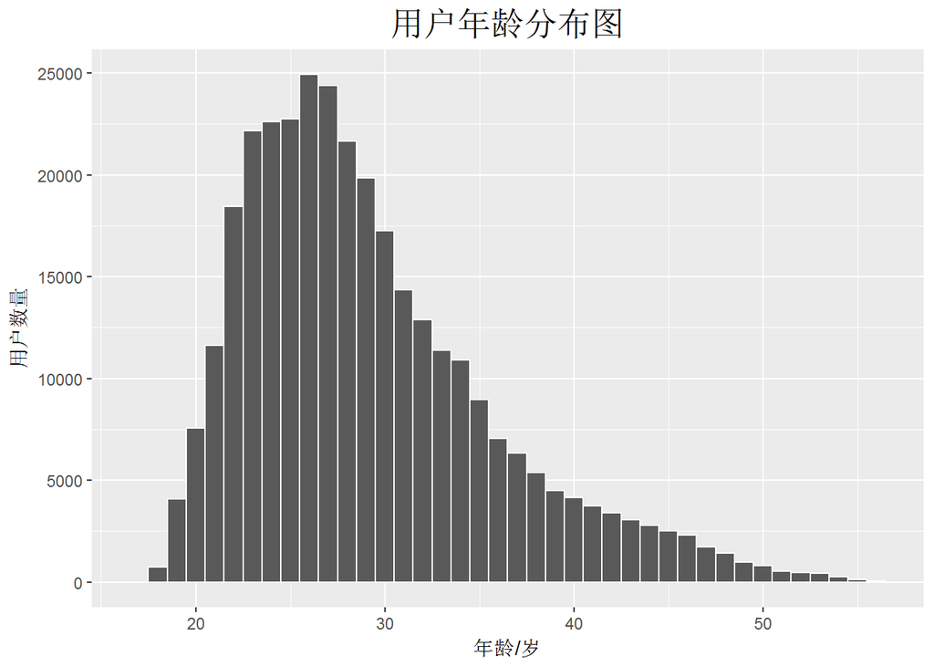

```
##    Min. 1st Qu.  Median    Mean 3rd Qu.    Max.
##   17.00   24.00   28.00   29.14   33.00   56.00
```

从图中可以看出，用户年龄集中在21-34岁之间，也就是1981-1994年出生的80后和95前人群；从summary中可以看出，用户的平均年龄为29岁，最年轻的为17岁，最年老的为56岁。

### 用户性别分布情况

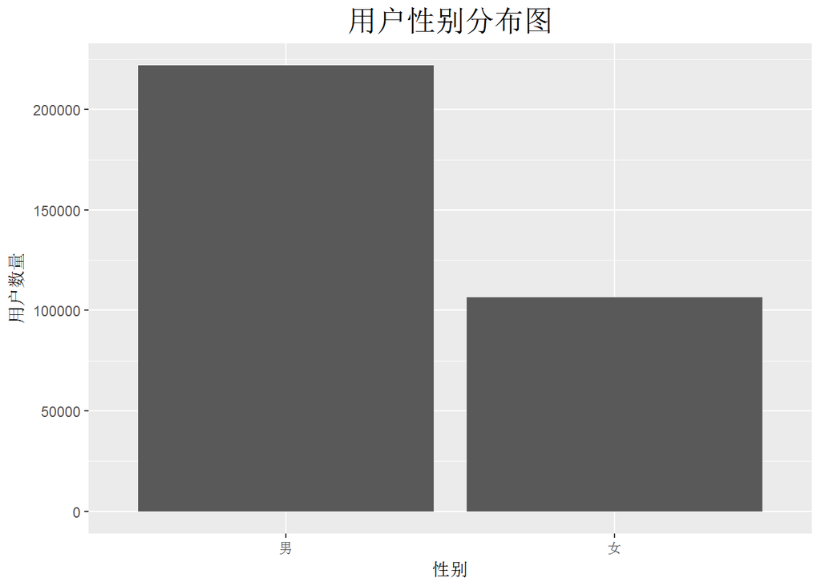

```
##
##     男     女
## 221946 106607
```

从图中可以看出，男性用户占到了2/3，女性用户占到了1/3.

### 用户身份认证情况

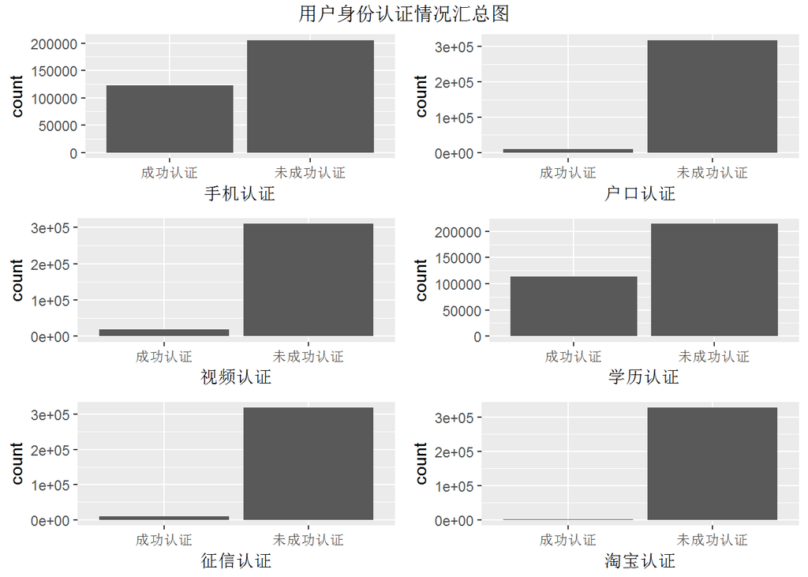

从图中可以看出，已完成手机认证和学历认证的用户占比均为1/3左右，但是其余几项中，成功认证的用户非常非常少。

为方便之后进行分析比较，现将几项认证合并为一个变量`认证情况`，若有成功认证的项则加1，若未成功认证则不变。

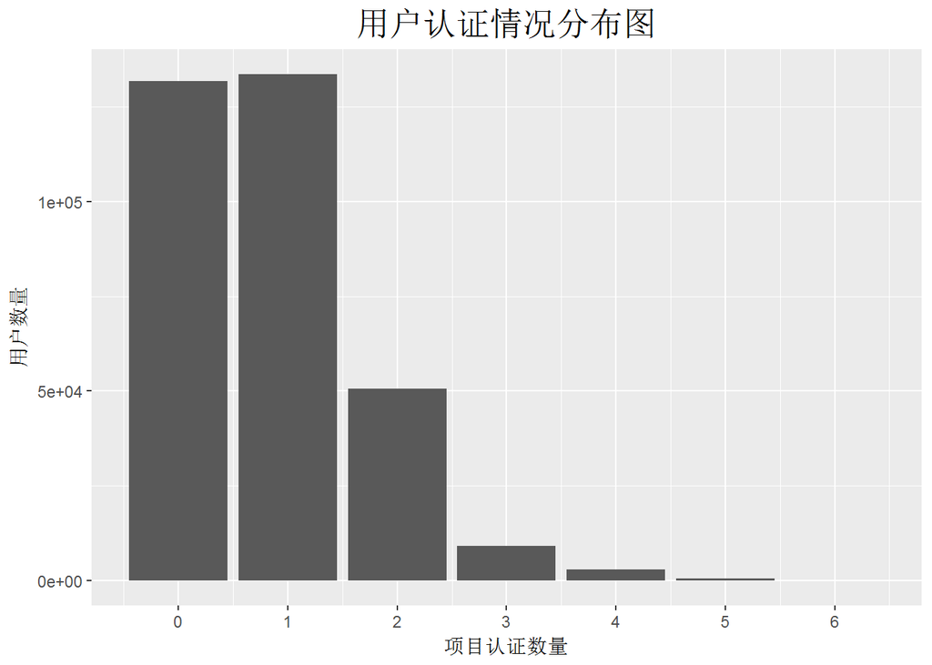

从上图中可以看出，大部分用户的认证种类在1项及以下，有两项以上认证的都很少。

### 历史成功借款次数分布情况

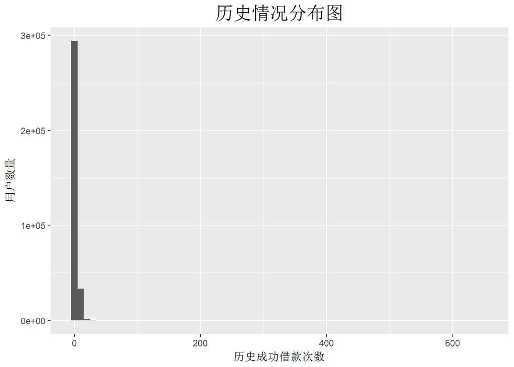

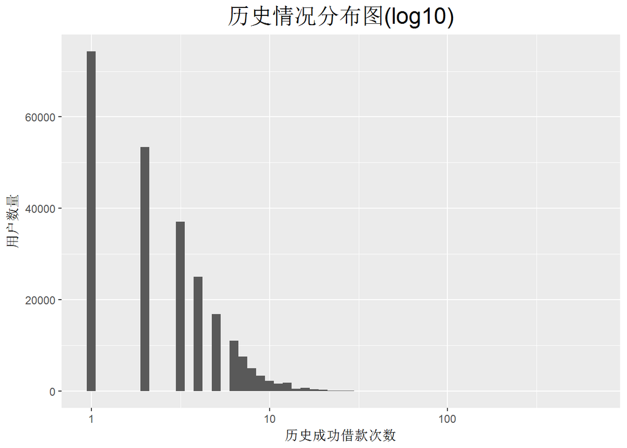

```
##    Min. 1st Qu.  Median    Mean 3rd Qu.    Max.
##   0.000   0.000   2.000   2.323   3.000 649.000
```

为方便查看用户的历史成功借款次数，将x轴转为对数坐标，从上图中可以看出，绝大部分用户的借款次数小于10次。

### 历史成功借款金额分布情况

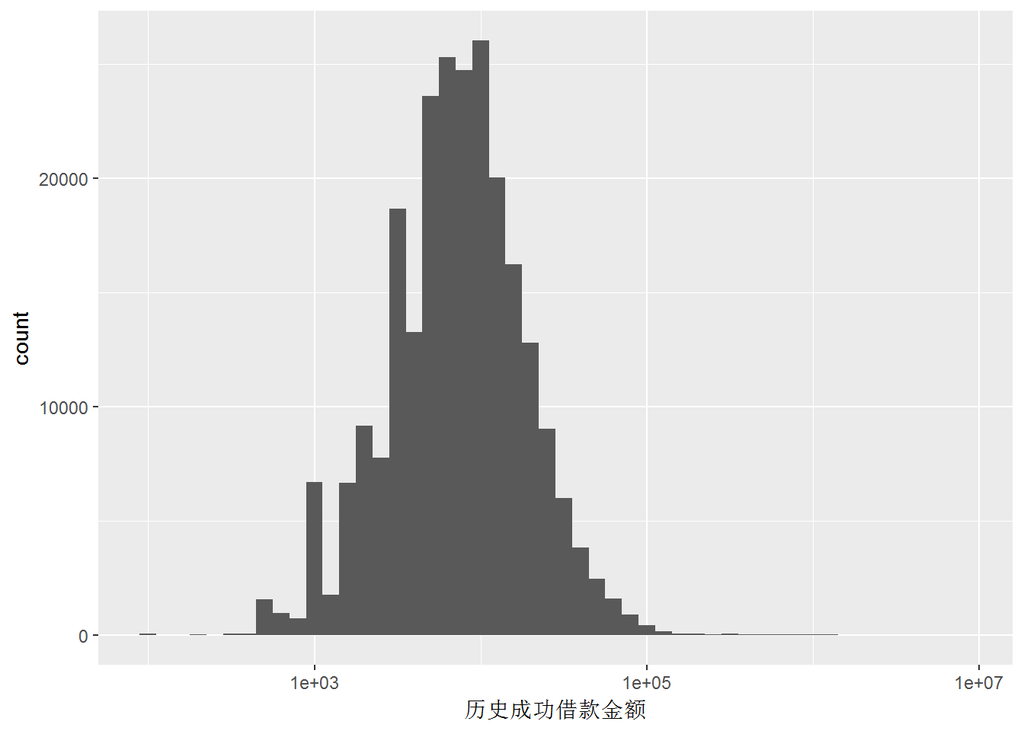

```
##    Min. 1st Qu.  Median    Mean 3rd Qu.    Max.
##       0       0    5000    8786   10355 7405926
```

从上图中可以看出，绝大部分用户的历史成功借款金额在1000-100000元之间。均值为8786元。

同样我们对历史成功借款金额进行分组，如下所示：  
(0,1000]  
(1000,10000]  
(10000,50000]  
(50000,100000] (100000,8000000]

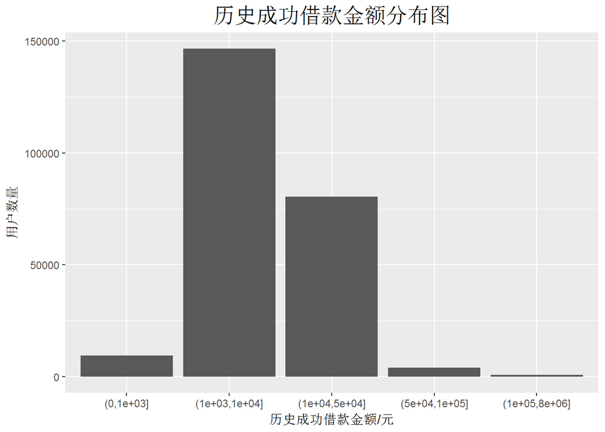

从上图中可以看出，用户的历史成功借款金额主要集中在1000-50000元之间。

## 单变量分析

### 数据集结构

现数据集lc中包含了328553个用户的借贷数据，25个变量。综合上述分析，我们选择了其中13 个变量进行分析，包括借款金额、借款期限、借款利率、初始评级、借款类型、年龄、性别、历史成功借款次数、历史成功借款金额、逾期比、借款金额.bucket、认证情况、历史成功借款金额.bucket，其中有6个数值变量，分别为：借款金额、借款利率、年龄、历史成功借款次数、历史成功借款金额、逾期比；其余均为分类变量。  
针对以上单变量的可视化结果，总结如下：

- 大部分人的逾期比在0.25以下，整体均值为0.04，但也不乏有超过0.5的用户；
- 借款金额主要集中在2000-5000元；
- 绝大部分人选择半年或一年的还款周期；
- 借款利率基本上都在20%及以上；
- 用户的初始评级集中在C和D等级；
- 借款用户中有3/4的都是老用户；
- 用户年龄主要集中在21-34岁之间，男性占到了用户总量的2/3；
- 用户的身份认证情况十分不好，只有少量的用户完成了超过2种项目的认证；
- 绝大部分用户借款次数少于10次，他们的借款金额总量集中在1000-50000元之间。

### 数据集中最主要的变量

当然是‘逾期比’，因为该变量实现了对用户逾期行为的量化，通过我们对其他特征与逾期比的相关性分析，指出具有哪些特性的用户最容易出现逾期行为，从而指引企业更直观更具体地去评估和筛选借贷用户。

### 你认为数据集内哪些其他特征可以帮助你探索兴趣特点？

在`数据集结构`中选择的那些变量都是有可能与逾期比有一定相关关系的特征，我觉得借款金额与借款期限会是相关性比较高的两项，因为金额和期限直接决定了用户还款压力的大小以及还款周期的长短，从而对逾期行为产生影响。

### 根据数据集内已有变量，创建了新变量

- 逾期比：逾期还款次数占总还款次数的比
- 认证情况：将所有项的认证情况进行了整合，只关心认证数量
- 借款金额.bucket：对用户的借款金额进行了分组
- 历史成功借款金额.bucket：对用户的历史成功借款金额进行了分组

### 在已经探究的特性中，是否存在任何异常分布？你是否对数据进行一些操作，如清洁、调整或改变数据的形式？如果是，你为什么会这样做？

在对用户借款金额，历史成功借款次数和历史成功借款金额的可视化中，将x轴变为了对数形式，这对于分布较为分散的变量可以看起来更集中一些，从而能更直观地得出结论；

在已探究的特性中，并没有发现异常值，不过有意思的是我在变量“历史成功借款次数”探究过程中，以为存在异常值649，但查看该行数据后，发现并不是异常值；同理，该用户的“历史成功借款金额”、“历史正常还款期数”和“历史逾期还款期数”均为正常值。

## 双变量绘图选择

### 拍拍贷各变量之间的关系

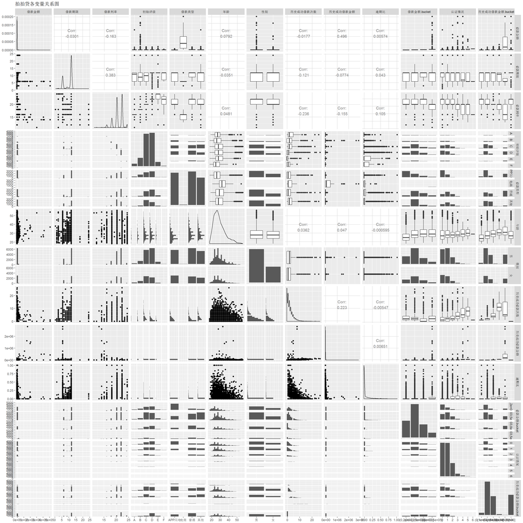

从上图中，我们并不能找出一对相关性较强的变量。

### 主要特性与其他特性之间的关系探究

### 逾期比与借款金额之间的关系

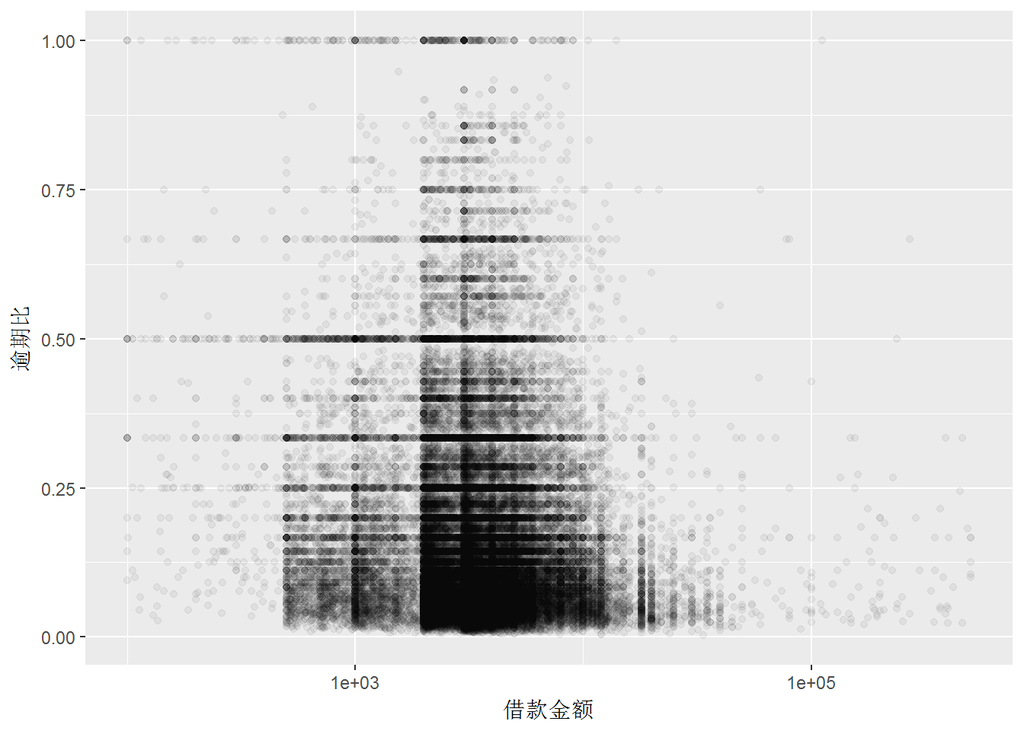

```
##
##  Pearson's product-moment correlation
##
## data:  lc$借款金额 and lc$逾期比
## t = 2.3158, df = 239600, p-value = 0.02057
## alternative hypothesis: true correlation is not equal to 0
## 95 percent confidence interval:
##  0.000726993 0.008734983
## sample estimates:
##         cor
## 0.004731064
```

从上图中可以看出，在借款金额较为集中的部分也是逾期比较高的部分，但二者几乎是毫不相关的。

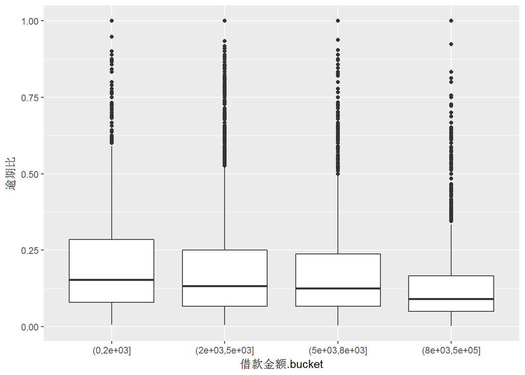

```
## subset(lc, 逾期比 > 0)$借款金额.bucket: (0,2e+03]
##     Min.  1st Qu.   Median     Mean  3rd Qu.     Max.
## 0.006536 0.080000 0.153846 0.212137 0.285714 1.000000
## --------------------------------------------------------
## subset(lc, 逾期比 > 0)$借款金额.bucket: (2e+03,5e+03]
##     Min.  1st Qu.   Median     Mean  3rd Qu.     Max.
## 0.005348 0.066667 0.133333 0.188293 0.250000 1.000000
## --------------------------------------------------------
## subset(lc, 逾期比 > 0)$借款金额.bucket: (5e+03,8e+03]
##     Min.  1st Qu.   Median     Mean  3rd Qu.     Max.
## 0.004706 0.066667 0.125000 0.175310 0.238095 1.000000
## --------------------------------------------------------
## subset(lc, 逾期比 > 0)$借款金额.bucket: (8e+03,5e+05]
##     Min.  1st Qu.   Median     Mean  3rd Qu.     Max.
## 0.002809 0.050000 0.090909 0.132729 0.166667 1.000000
```

从上图中可以看出，借款金额较低时，逾期比更为分散，且中位数也较高;就均值而言，借款金额达到8000以上的用户，逾期比也是最低的。

### 逾期比与借款期限之间的关系

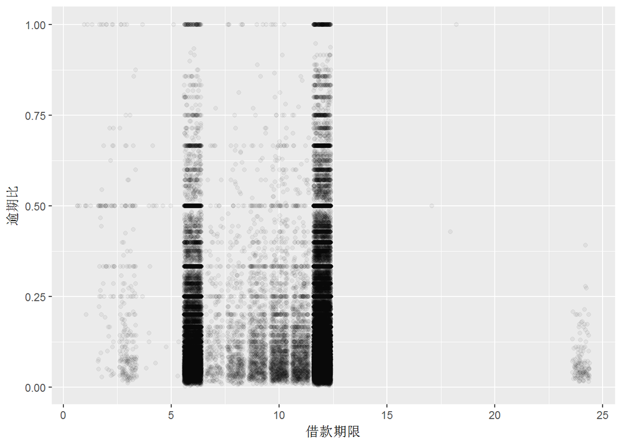

```
##
##  Pearson's product-moment correlation
##
## data:  lc$借款期限 and lc$逾期比
## t = 18.413, df = 239600, p-value < 2.2e-16
## alternative hypothesis: true correlation is not equal to 0
## 95 percent confidence interval:
##  0.03359208 0.04158893
## sample estimates:
##        cor
## 0.03759111
```

从上图中可以看出，在借款期限为半年和一年的位置，借款人数最多，逾期比也相对较高。显然，二者相关性很低。

### 逾期比与借款利率之间的关系

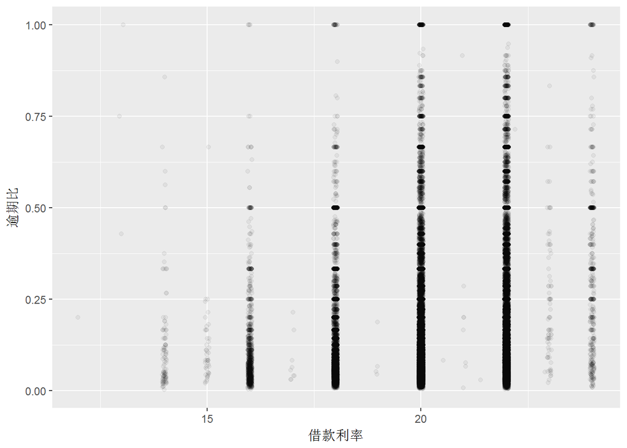

```
##
##  Pearson's product-moment correlation
##
## data:  lc$借款利率 and lc$逾期比
## t = 56.248, df = 239600, p-value < 2.2e-16
## alternative hypothesis: true correlation is not equal to 0
## 95 percent confidence interval:
##  0.1102073 0.1181111
## sample estimates:
##      cor
## 0.114161
```

从上图中可以看出，用户选择较多的借款利率中，逾期比也较高。显然，二者也几乎不相关。

### 逾期比与初始评级之间的关系

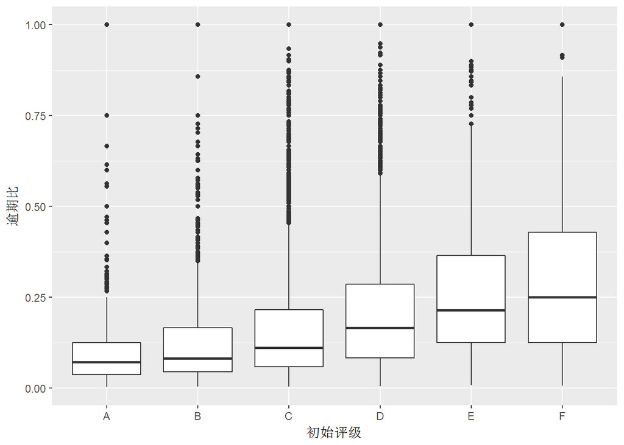

```
## subset(lc, 逾期比 > 0)$初始评级: A
##     Min.  1st Qu.   Median     Mean  3rd Qu.     Max.
## 0.002809 0.037037 0.071429 0.111499 0.125000 1.000000
## --------------------------------------------------------
## subset(lc, 逾期比 > 0)$初始评级: B
##     Min.  1st Qu.   Median     Mean  3rd Qu.     Max.
## 0.003577 0.045455 0.082483 0.134613 0.166667 1.000000
## --------------------------------------------------------
## subset(lc, 逾期比 > 0)$初始评级: C
##     Min.  1st Qu.   Median     Mean  3rd Qu.     Max.
## 0.004049 0.058824 0.111111 0.163113 0.216329 1.000000
## --------------------------------------------------------
## subset(lc, 逾期比 > 0)$初始评级: D
##     Min.  1st Qu.   Median     Mean  3rd Qu.     Max.
## 0.005464 0.083333 0.166667 0.210350 0.285714 1.000000
## --------------------------------------------------------
## subset(lc, 逾期比 > 0)$初始评级: E
##     Min.  1st Qu.   Median     Mean  3rd Qu.     Max.
## 0.008403 0.125000 0.214286 0.272981 0.365463 1.000000
## --------------------------------------------------------
## subset(lc, 逾期比 > 0)$初始评级: F
##     Min.  1st Qu.   Median     Mean  3rd Qu.     Max.
## 0.007299 0.125658 0.250000 0.299723 0.428571 1.000000
```

从上图中可以看出，随着用户评级越来越低（A至F），逾期比越来越分散，中位数也越来越高。就逾期比的均值而言，也是随用户评级降低而不断升高。

### 逾期比与借款类型之间的关系

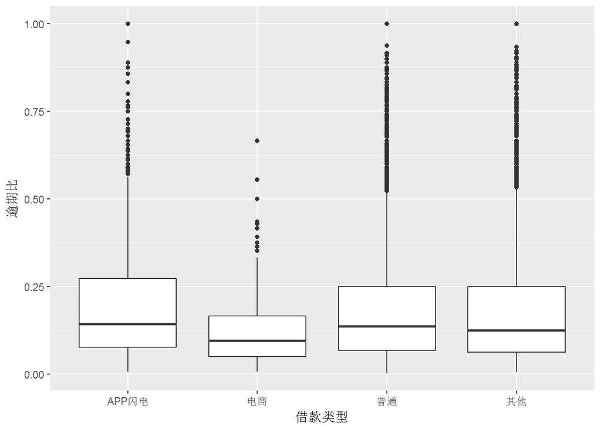

```
## subset(lc, 逾期比 > 0)$借款类型: APP闪电
##     Min.  1st Qu.   Median     Mean  3rd Qu.     Max.
## 0.006536 0.076923 0.142857 0.205658 0.272727 1.000000
## --------------------------------------------------------
## subset(lc, 逾期比 > 0)$借款类型: 电商
##     Min.  1st Qu.   Median     Mean  3rd Qu.     Max.
## 0.006536 0.050000 0.096580 0.139717 0.166667 0.666667
## --------------------------------------------------------
## subset(lc, 逾期比 > 0)$借款类型: 普通
##     Min.  1st Qu.   Median     Mean  3rd Qu.     Max.
## 0.002809 0.068182 0.136364 0.190104 0.250000 1.000000
## --------------------------------------------------------
## subset(lc, 逾期比 > 0)$借款类型: 其他
##     Min.  1st Qu.   Median     Mean  3rd Qu.     Max.
## 0.005618 0.062500 0.125000 0.177342 0.250000 1.000000
```

从上图中可以看出，逾期比与借款类型之间并无明显关系。

### 逾期比与年龄之间的关系

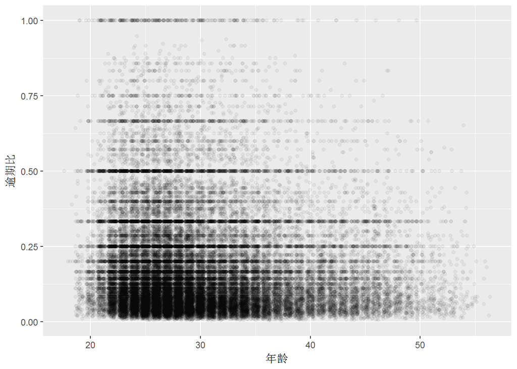

从上图中可以看出，在用户较为集中的年龄段，逾期比也较高。

### 逾期比与性别之间的关系

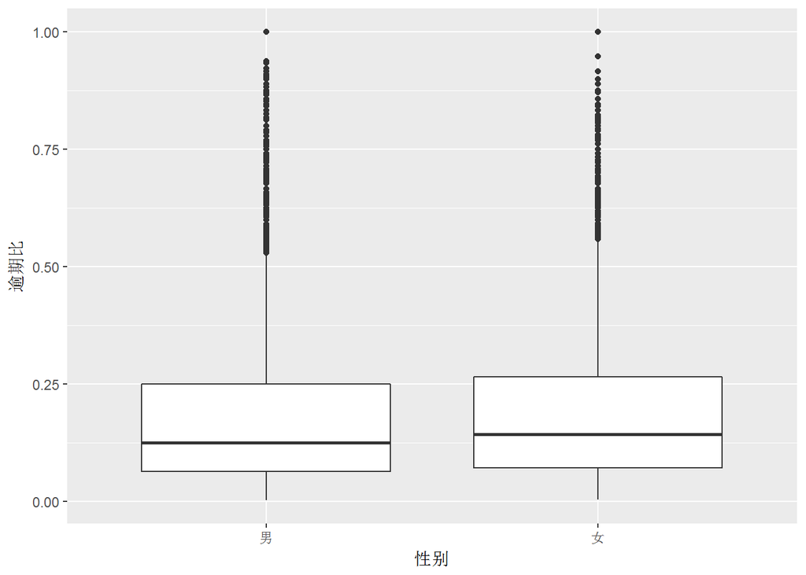

从上图中可以看出，逾期比与性别之间并无明显关系。

### 逾期比与历史成功借款次数之间的关系

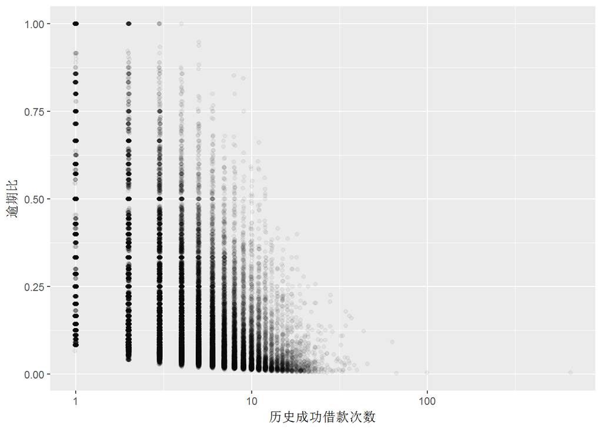

```
##
##  Pearson's product-moment correlation
##
## data:  subset(lc, 逾期比 > 0)$历史成功借款次数 and subset(lc, 逾期比 > 0)$逾期比
## t = -67.702, df = 50366, p-value < 2.2e-16
## alternative hypothesis: true correlation is not equal to 0
## 95 percent confidence interval:
##  -0.2967998 -0.2807903
## sample estimates:
##        cor
## -0.2888152
```

从上图中可以看出，历史成功借款次数越多，逾期比也就相对越低，二者有较低的负相关性。

### 逾期比与历史成功借款金额之间的关系

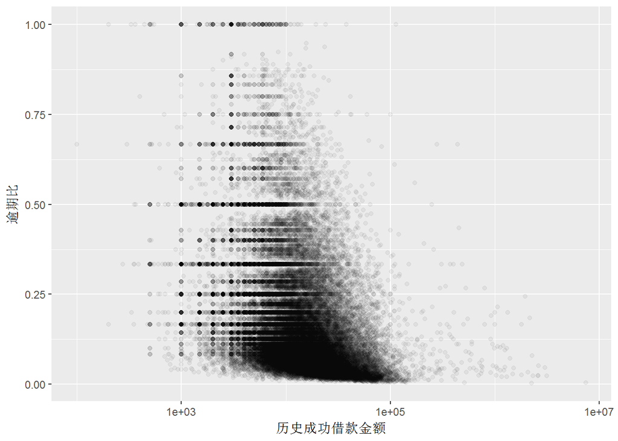

从上图中可以看出，在用户较为集中的区间，逾期比相对较高。

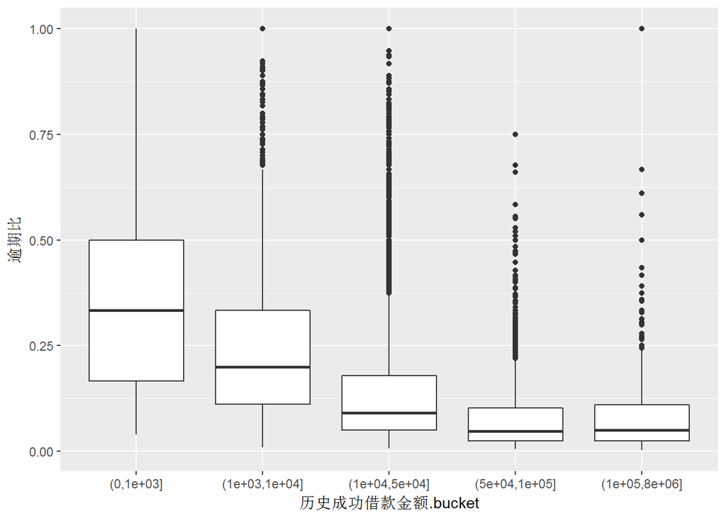

从上图中可以看出，历史成功借款金额越高，逾期比会越集中，且中位数也会越低。

### 逾期比与认证情况之间的关系

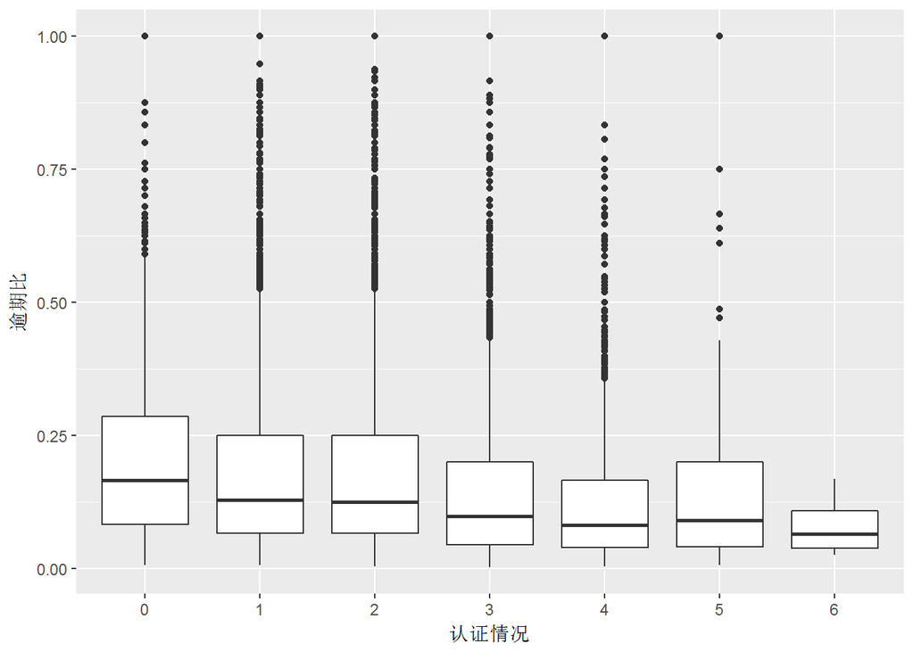

从上图中可以看出，用户认证的项目数量越多，逾期比越集中，逾期比高于0.5的用户也越来越少。

### 其他特性之间的关系探究

### 用户中，不同性别的年龄构成如何？

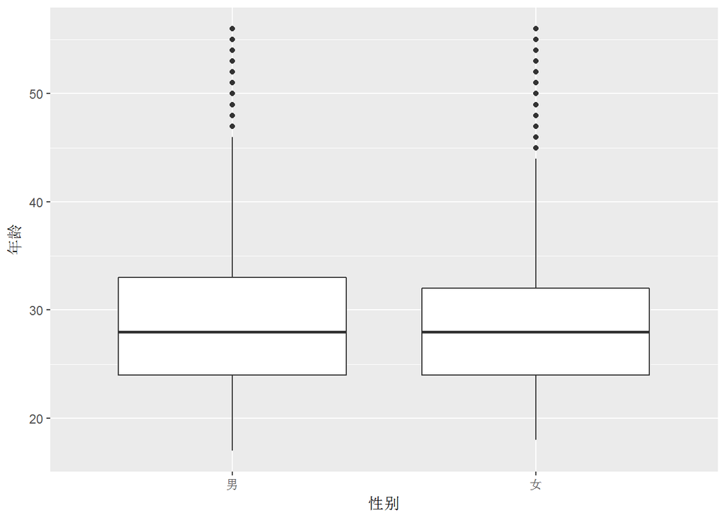

```
## lc$性别: 男
##    Min. 1st Qu.  Median    Mean 3rd Qu.    Max.
##   17.00   24.00   28.00   29.28   33.00   56.00
## --------------------------------------------------------
## lc$性别: 女
##    Min. 1st Qu.  Median    Mean 3rd Qu.    Max.
##   18.00   24.00   28.00   28.86   32.00   56.00
```

从上图中可以看出，用户中男女的年龄构成基本一致。

### 借款期限与借款利率之间的关系

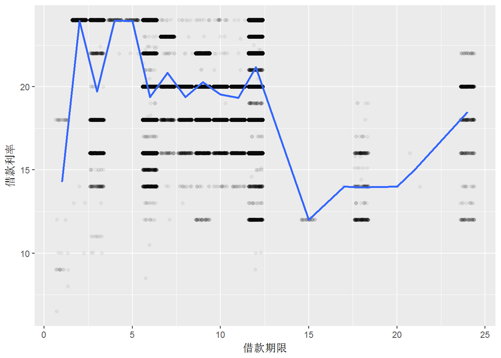

从上图中可以看出，在借款期限低于5个月时的借款利率相对较高；借款期限在5-12个月之间时，借款利率相对较低。